# StockResearch

Gabriel Foix

2021-01-03

Buy Quality at the a good momentum and get rid of the fishy stocks on time. That's all.

### Define candidates

Download all info needed applying the following filters:

### Factor 1: Quality

1. Healthy debts: A company shoud generate cash in order to repay its debt. The **Free Cash Flow to Debt** ratio is a good indicator of how quick a company pays back its debt. The lower this ratio the better.

FCF2D = $\frac{Debt}{Free Cash Flow}$

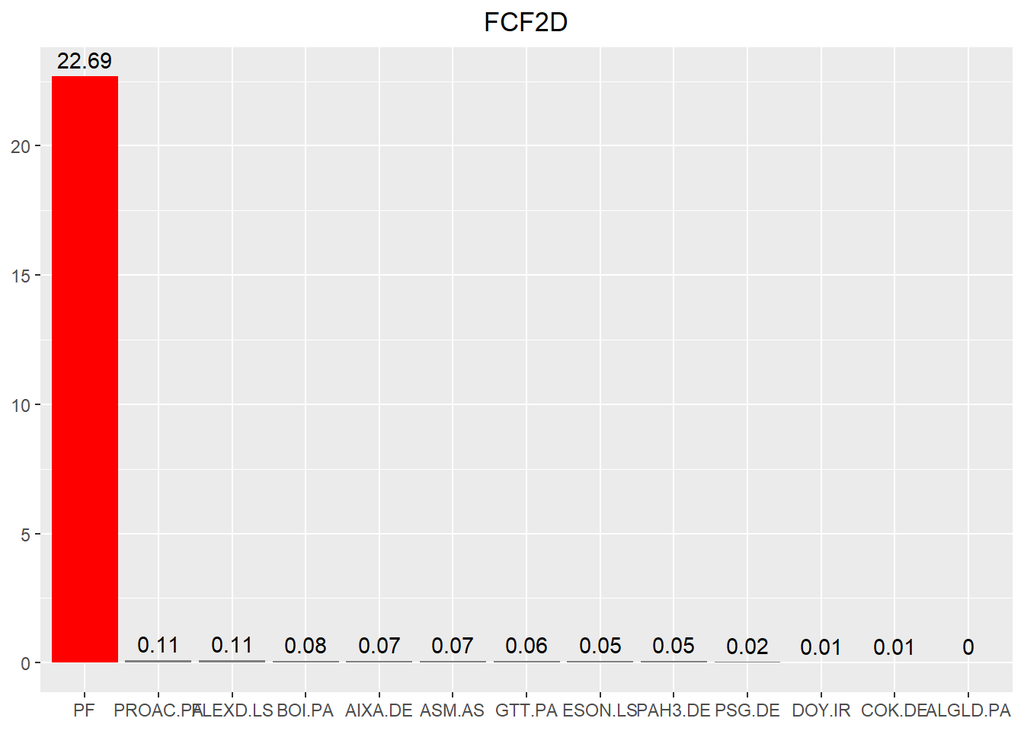

2. Profitability: ROA

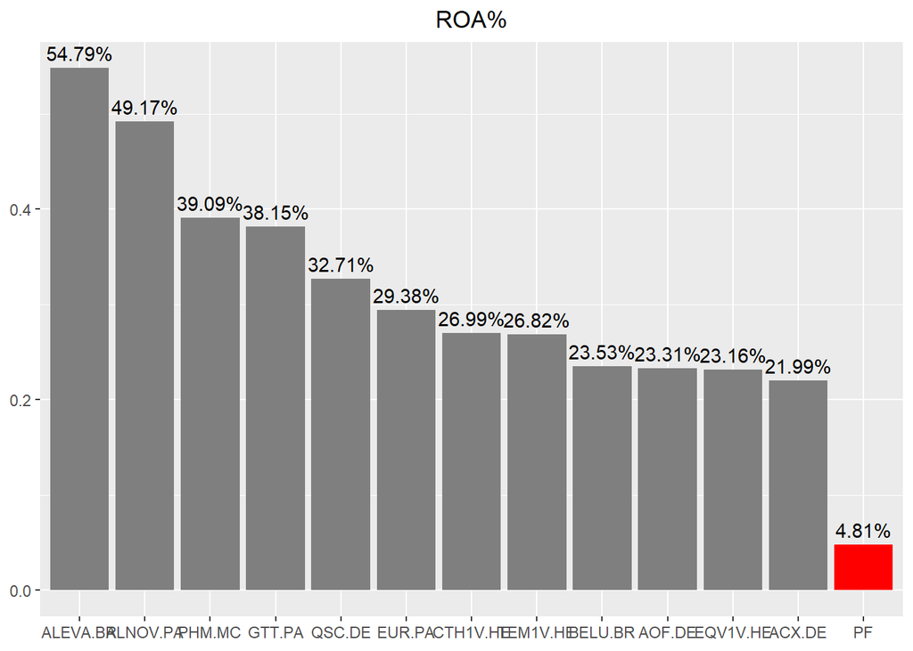

3. High Margin: We look for companies that generate free cash flow compare to its price. The **Free Cash Flow to Entreprise Value** ratio tells us how many years of cash flow would be needed to the return the 100% of the investment. Again, the lower, the better. Values bellow 1 would mean "free lunch".

FCF2EV = $\frac{EV}{Free Cash Flow}$

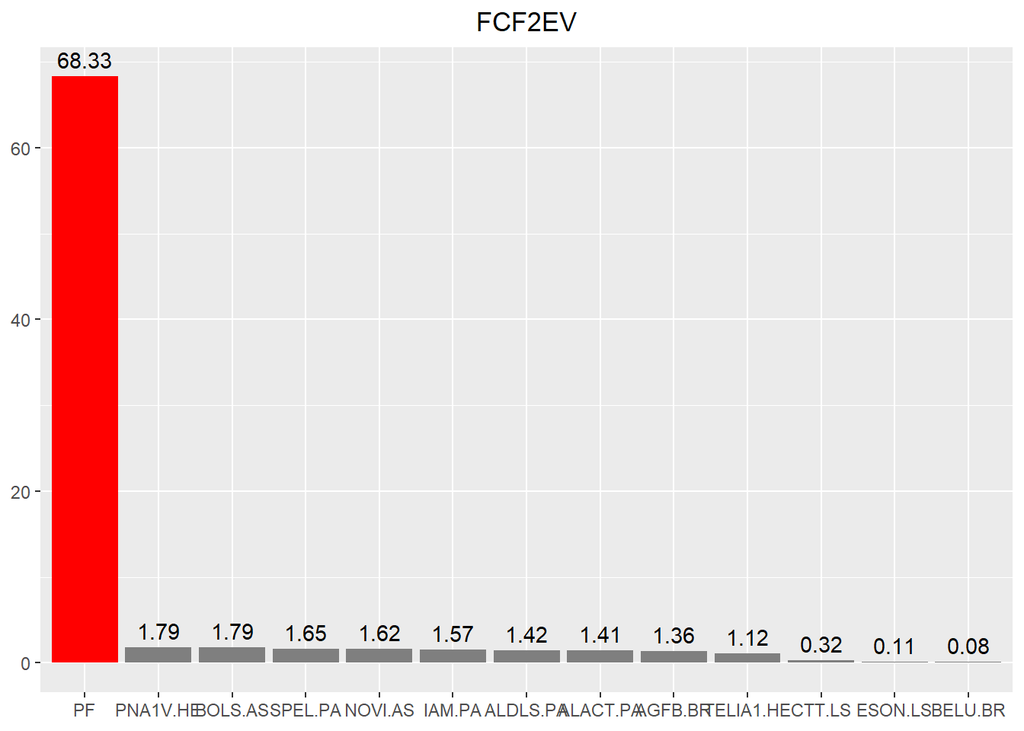

#### Download Historical Data

Download only stocks not filtered previously

### Value touch

Filter out stocks with PER > 40

Report Candidates

Filter Summary

| Filter | NStocks |
| --- | --- |
| Initial | 1577 |
| ROA | 879 |
| FCF | 778 |
| Hist1Y | 768 |
| PER | 493 |

### Factor 2: Momentum

Don't hold onto a stock simply because it is high quality. So called quality stocks have cycles too. Stan Weinstein (page 177)

Generic Intermediate-Term Momentum Based on Gray-Vogel (page 80)

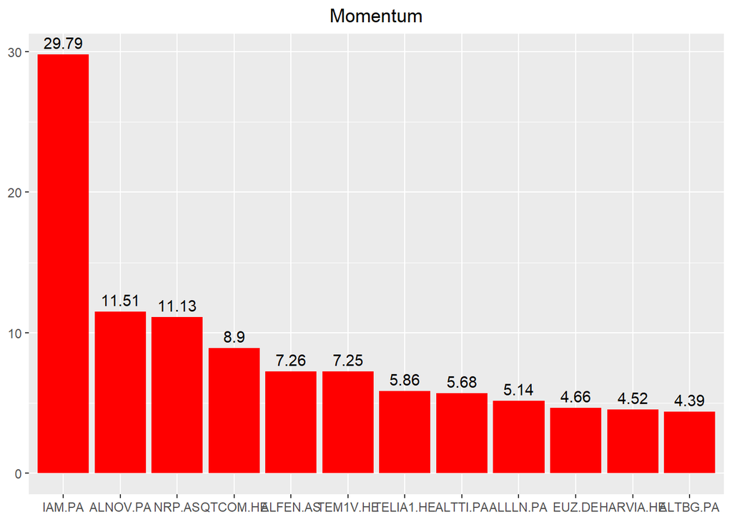

### Factor 3: Timing Signal

Sell Signal - Pr < 1% SMA 30 weeks and slope negative (< -0.2)  
Buy Signal - 109% * SMA30 < Pr > SMA 30 and slope positive (> 0.2)  
Hold Signal - Neither Buy nor Sell

#### Calc Market Cap

Using free float shares

### Summary

Summary

| Ticker | Signal | Quality | Momentum | Final_rank | PER | MCap |
| --- | --- | --- | --- | --- | --- | --- |
| BELU.BR | BUY | 871.0 | 709 | 850.0 | 1.933333 | NA |
| PAY.BR | BUY | 844.0 | 721 | 844.5 | 14.910537 | 44823248 |
| TELIA1.HE | HOLD | 764.0 | 762 | 839.5 | 26.000001 | 8364132218 |
| DQ5.IR | HOLD | 843.0 | 683 | 839.5 | 14.854111 | 224307839 |
| ALMIC.PA | HOLD | 799.0 | 725 | 838.0 | 36.285714 | 68248732 |
| ORDI.AS | HOLD | 818.0 | 699 | 837.0 | 13.956311 | 223990485 |
| DIGIA.HE | HOLD | 777.0 | 731 | 834.0 | 24.495114 | 118763976 |
| ALNOV.PA | HOLD | 737.0 | 767 | 833.0 | 16.442953 | 641658472 |
| GTT.PA | HOLD | 806.5 | 685 | 831.0 | 14.588321 | 1733433305 |
| VBK.DE | HOLD | 740.0 | 744 | 828.0 | 23.453018 | 180362382 |
| ALREW.PA | HOLD | 837.0 | 640 | 827.0 | 6.876356 | 141626572 |
| ASM.AS | HOLD | 736.0 | 733 | 822.0 | 28.577100 | 8117142354 |
| MMO1V.HE | HOLD | 693.0 | 752 | 818.5 | 29.712981 | 173940780 |
| KNEBV.HE | HOLD | 765.0 | 660 | 816.0 | 36.718232 | 23577457472 |
| EQV1V.HE | HOLD | 738.0 | 686 | 815.0 | 31.018518 | 138378132 |
| DQ7A.IR | HOLD | 769.0 | 649 | 813.0 | 26.838966 | 28640102 |
| ZENT.BR | HOLD | 780.0 | 637 | 812.0 | 14.137483 | 28796731 |
| ALTXC.PA | HOLD | 774.0 | 641 | 811.0 | 13.322884 | 1930673 |
| ALDNX.PA | HOLD | 850.0 | 563 | 810.0 | 11.864904 | NA |
| RM.MI | BUY | 720.0 | 690 | 809.0 | 24.250001 | 153358514 |
| SCANFL.HE | HOLD | 801.5 | 603 | 808.0 | 9.716840 | 108148459 |
| CE2.DE | HOLD | 703.0 | 701 | 806.5 | 12.632696 | 266856777 |
| SPEL.PA | HOLD | 762.0 | 642 | 806.5 | 4.103535 | 16187743 |
| HOLCO.AS | HOLD | 857.0 | 546 | 804.0 | 11.558172 | 32512744 |
| DVT.PA | HOLD | 841.0 | 559 | 803.0 | 18.965166 | 162431660 |
| ORNBV.HE | SELL | 783.0 | 611 | 802.0 | 21.998827 | 4722442718 |
| WUF1V.HE | HOLD | 718.5 | 672 | 801.0 | 11.824818 | 5359339 |
| SO.PA | HOLD | 731.0 | 656 | 799.0 | 31.216218 | 1017133747 |
| VALMT.HE | HOLD | 776.0 | 608 | 797.5 | 16.473907 | 3087059261 |
| UPR.IR | BUY | 689.0 | 695 | 797.5 | 24.285715 | 504050997 |

[output cut: 463 more lines]

Save output in template